# Tugas MPDW - Regresi dengan Peubah Lag

# Input Data

```r
library(readxl)
dt <- read_excel("/Users/mrkahar/Downloads/NewDelhi_Air_quality-2.xlsx")
data <- dt[,c(1,2,6)]
data
```

```
## # A tibble: 72 × 3
##        t   AQI    o3
##    <dbl> <dbl> <dbl>
##  1     1  30.2  55.8
##  2     2  28.2  54.9
##  3     3  26.6  54.6
##  4     4  25    55.1
##  5     5  26    55.8
##  6     6  26    56.5
##  7     7  26    55.8
##  8     8  24    52.9
##  9     9  23    50.1
## 10    10  24    51.5
## # ℹ 62 more rows
```

# Pembagian Data

```r
train<-data[1:57,] # 80%
test<-data[58:72,] # 20%
```

```r
# Data time series
train.ts<-ts(train)
test.ts<-ts(test)
data.ts<-ts(data)
```

# Model Koyck

## Pemodelan

```r
model.koyck <- koyckDlm(x = train$o3, y = train$AQI)
summary(model.koyck)
```

```
##
## Call:
## "Y ~ (Intercept) + Y.1 + X.t"
##
## Residuals:
##       Min        1Q    Median        3Q       Max
## -1.127670 -0.301407  0.001002  0.262601  1.103471
##
## Coefficients:
##             Estimate Std. Error t value Pr(>|t|)
## (Intercept)  0.54798    0.92878   0.590    0.558
## Y.1          0.41955    0.08223   5.102 4.63e-06 ***
## X.t          0.25830    0.04107   6.289 6.25e-08 ***
## ---
## Signif. codes:  0 '***' 0.001 '**' 0.01 '*' 0.05 '.' 0.1 ' ' 1
##
## Residual standard error: 0.5053 on 53 degrees of freedom
## Multiple R-Squared: 0.9463,  Adjusted R-squared: 0.9443
## Wald test: 423.7 on 2 and 53 DF,  p-value: < 2.2e-16
##
## Diagnostic tests:
## NULL
##
##                             alpha      beta       phi
## Geometric coefficients:  0.944071 0.2582957 0.4195528
```

```r
AIC(model.koyck)
```

```
## [1] 87.39413
```

```r
BIC(model.koyck)
```

```
## [1] 95.49554
```

Dari hasil tersebut, diperoleh bahwa peubah $x_t$ dan $y_{t-1}$ memiliki nilai p < 0.05. Hal ini menunjukkan bahwa peubah $x_t$ dan $y_{t-1}$ berpengaruh signifikan terhadap $y$. Adapun model keseluruhannya sebagai berikut:
$$\hat{Y}_t = 0.54798 + 0.2583 X_t + 0.41955 Y_{t-1}$$

## Peramalan dan Akurasi

```r
fore.koyck <- forecast(model = model.koyck, x=test$o3, h=15)
fore.koyck
```

```
## $forecasts
##  [1] 24.15387 23.05989 21.95429 21.12094 20.21706 19.74546 20.00947 20.67448
##  [9] 20.95348 21.07054 21.58152 23.08914 24.83015 26.29958 27.28558
##
## $call
## forecast.koyckDlm(model = model.koyck, x = test$o3, h = 15)
##
## attr(,"class")
## [1] "forecast.koyckDlm" "dLagM"
```

```r
# Akurasi data test
mape.koyck <- MAPE(fore.koyck$forecasts, test$AQI)
mape.koyck
```

```
## [1] 0.03187326
```

```r
# Akurasi data train
GoF(model.koyck)
```

```
##              n       MAE         MPE       MAPE      sMAPE      MASE       MSE
## model.koyck 56 0.3849916 -0.00049635 0.01435646 0.01433475 0.6015494 0.2416839
##                  MRAE    GMRAE
## model.koyck 589435374 7663.933
```

**Kesimpulan:**

1. Data hasil ramalan mengalami penurunan pada 6 periode awal kemudian meningkat sampai periode ke-15.
2. Nilai MAPE pada data testing dan training di bawah 10%, artinya tidak terindikasi adanya overfitting/underfitting pada model.

# Regression with Distributed Lag

## Pemodelan (Lag=2)

```r
model.dlm <- dlm(x = train$o3,y = train$AQI , q = 2)
summary(model.dlm)
```

```
##
## Call:
## lm(formula = model.formula, data = design)
##
## Residuals:
##      Min       1Q   Median       3Q      Max
## -0.45678 -0.35809 -0.02571  0.25176  1.40513
##
## Coefficients:
##              Estimate Std. Error t value Pr(>|t|)
## (Intercept) -0.052782   0.689979  -0.076    0.939
## x.t          0.476379   0.053816   8.852 6.95e-12 ***
## x.1         -0.005756   0.099095  -0.058    0.954
## x.2         -0.008392   0.055411  -0.151    0.880
## ---
## Signif. codes:  0 '***' 0.001 '**' 0.01 '*' 0.05 '.' 0.1 ' ' 1
##
## Residual standard error: 0.3501 on 51 degrees of freedom
## Multiple R-squared:  0.9751, Adjusted R-squared:  0.9736
## F-statistic:   666 on 3 and 51 DF,  p-value: < 2.2e-16
##
## AIC and BIC values for the model:
##       AIC      BIC
## 1 46.4728 56.50947
```

Dari hasil tersebut, diperoleh bahwa peubah $x_t$ memiliki nilai p < 0.05. Hal ini menunjukkan bahwa peubah $x_t$ berpengaruh signifikan terhadap $y$. Adapun model keseluruhannya sebagai berikut:
$$\hat{Y}_t = -0.05278 + 0.47638 X_t - 0.00576 X_{t-1} - 0.0084 X_{t-2}$$

```r
# Peramalan dan akurasi
fore.dlm <- forecast(model = model.dlm, x=test$o3, h=15)
fore.dlm
```

```
## $forecasts
##  [1] 23.34620 22.02786 20.88178 20.23873 19.24577 19.09976 19.97166 20.98657
##  [9] 20.95921 20.94120 21.79304 24.16788 26.16845 27.46467 28.09365
##
## $call
## forecast.dlm(model = model.dlm, x = test$o3, h = 15)
##
## attr(,"class")
## [1] "forecast.dlm" "dLagM"
```

```r
# Akurasi data test
mape.dlm <- MAPE(fore.dlm$forecasts, test$AQI)
mape.dlm
```

```
## [1] 0.006820359
```

```r
# Akurasi data train
GoF(model.dlm)
```

```
##            n       MAE           MPE       MAPE       sMAPE      MASE       MSE
## model.dlm 55 0.2667435 -0.0001491955 0.00988322 0.009894614 0.4286949 0.1136382
##                 MRAE    GMRAE
## model.dlm 1030460869 6714.446
```

## Pemodelan Lag Optimum

```r
# Menentukan lag optimum
finiteDLMauto(formula = AQI ~ o3,
              data = data.frame(train), q.min = 1, q.max = 10,
              model.type = "dlm", error.type = "AIC", trace = TRUE)
```

```
##    q - k    MASE      AIC      BIC     GMRAE   MBRAE R.Adj.Sq  Ljung-Box
## 10    10 0.35051 22.97129 47.02321 14499.820 0.49589  0.98302 0.35474502
## 3      3 0.39875 27.06744 39.00134  6447.089 0.49480  0.98198 0.10728965
## 5      5 0.38245 27.17252 42.78247  7468.898 0.49506  0.98252 0.17930776
## 4      4 0.39892 27.90158 41.69362  8742.382 0.49838  0.98187 0.16589034
## 9      9 0.38342 29.59952 52.05393 11575.966 0.50164  0.98105 0.83879203
## 6      6 0.38046 29.81810 47.20453  6019.920 0.48473  0.98200 0.19113496
## 7      7 0.39444 30.91101 50.03124  7435.980 0.49025  0.98199 0.27024407
## 8      8 0.40121 31.26668 52.07671 10182.702 0.51165  0.98151 0.41738843
## 2      2 0.42869 46.47280 56.50947  6714.446 0.48891  0.97365 0.08751929
## 1      1 0.50971 90.38861 98.49001  6923.684 0.40817  0.94126 0.16081431
```

Berdasarkan hasil tersebut, lag optimum diperoleh ketika **lag = 10.** Ditinjau dari nilai **AIC terendah** dan **R Squared Adj tertinggi.**

```r
# Pemodelan dengan lag optimum
model.dlm2 <- dlm(x = train$o3,y = train$AQI , q = 10)
summary(model.dlm2)
```

```
##
## Call:
## lm(formula = model.formula, data = design)
##
## Residuals:
##     Min      1Q  Median      3Q     Max
## -0.5204 -0.1663  0.0356  0.1624  0.5130
##
## Coefficients:
##              Estimate Std. Error t value Pr(>|t|)
## (Intercept) -0.294780   0.931786  -0.316  0.75361
## x.t          0.405638   0.063702   6.368 2.54e-07 ***
## x.1          0.159000   0.133129   1.194  0.24038
## x.2         -0.052741   0.126788  -0.416  0.67997
## x.3         -0.148621   0.121282  -1.225  0.22860
## x.4          0.143544   0.124404   1.154  0.25638
## x.5         -0.007047   0.123348  -0.057  0.95476
## x.6         -0.127683   0.123191  -1.036  0.30709
## x.7          0.287823   0.121937   2.360  0.02396 *
## x.8         -0.399437   0.121443  -3.289  0.00230 **
## x.9          0.304147   0.103813   2.930  0.00594 **
## x.10        -0.098958   0.048025  -2.061  0.04684 *
## ---
## Signif. codes:  0 '***' 0.001 '**' 0.01 '*' 0.05 '.' 0.1 ' ' 1
##
## Residual standard error: 0.2715 on 35 degrees of freedom
## Multiple R-squared:  0.9871, Adjusted R-squared:  0.983
## F-statistic: 243.1 on 11 and 35 DF,  p-value: < 2.2e-16
##
## AIC and BIC values for the model:
##        AIC      BIC
## 1 22.97129 47.02321
```

Dari hasil tersebut, diperoleh bahwa peubah $x_t$, $x_{t-7}$, $x_{t-8}$, $x_{t-9}$, $x_{t-10}$ memiliki nilai p < 0.05. Hal ini menunjukkan bahwa peubah $x_t$, $x_{t-7}$, $x_{t-8}$, $x_{t-9}$, $x_{t-10}$ berpengaruh signifikan terhadap $y$. Adapun model keseluruhannya sebagai berikut:
$$\hat{Y}_t = -0.29478 + 0.40564 X_t + 0.159 X_{t-1} - 0.05274 X_{t-2} -
0.14862 X_{t-3} + 0.14354 X_{t-4} - 0.00705 X_{t-5} - 0.12768 X_{t-6} +
0.28782 X_{t-7} - 0.39944 X_{t-8} + 0.30415 X_{t-9} - 0.09896 X_{t-10}$$

```r
# Peramalan dan akurasi
fore.dlm2 <- forecast(model = model.dlm2, x=test$o3, h=15)
fore.dlm2
```

```
## $forecasts
##  [1] 23.40514 21.79122 20.75754 20.09325 19.25114 18.84865 19.56151 20.98076
##  [9] 21.17891 20.56410 21.57565 23.70751 26.47347 27.65902 27.98734
##
## $call
## forecast.dlm(model = model.dlm2, x = test$o3, h = 15)
##
## attr(,"class")
## [1] "forecast.dlm" "dLagM"
```

```r
# Akurasi data test
mape.dlm2<- MAPE(fore.dlm2$forecasts, test$AQI)
mape.dlm2
```

```
## [1] 0.01274404
```

```r
# Aakurasi data train
GoF(model.dlm2)
```

```
##             n      MAE           MPE        MAPE       sMAPE      MASE
## model.dlm2 47 0.198112 -6.467038e-05 0.007238929 0.007234284 0.3505059
##                   MSE      MRAE    GMRAE
## model.dlm2 0.05489584 894254642 14499.82
```

**Kesimpulan:**

1. Data hasil ramalan mengalami penurunan pada 6 periode awal kemudian meningkat sampai periode ke-15 walaupun sempat ada penurunan pada periode ke-10.
2. Nilai MAPE pada data testing dan training di bawah 10%, artinya tidak terindikasi adanya overfitting/underfitting pada model.

# Model Autoregressive

## Pemodelan

```r
model.ardl <- ardlDlm(AQI ~ o3, data = train, p = 1 , q = 1)
summary(model.ardl)
```

```
##
## Time series regression with "ts" data:
## Start = 2, End = 57
##
## Call:
## dynlm(formula = as.formula(model.text), data = data)
##
## Residuals:
##     Min      1Q  Median      3Q     Max
## -1.0261 -0.2582  0.1254  0.2988  0.8683
##
## Coefficients:
##             Estimate Std. Error t value Pr(>|t|)
## (Intercept) -0.14906    0.67926  -0.219    0.827
## o3.t         0.47821    0.03429  13.946  < 2e-16 ***
## o3.1        -0.22331    0.04692  -4.759 1.59e-05 ***
## AQI.1        0.45264    0.06656   6.801 1.03e-08 ***
## ---
## Signif. codes:  0 '***' 0.001 '**' 0.01 '*' 0.05 '.' 0.1 ' ' 1
##
## Residual standard error: 0.3812 on 52 degrees of freedom
## Multiple R-squared:   0.97,  Adjusted R-squared:  0.9683
## F-statistic: 561.2 on 3 and 52 DF,  p-value: < 2.2e-16
```

```r
AIC(model.ardl)
```

```
## [1] 56.75817
```

```r
BIC(model.ardl)
```

```
## [1] 66.88493
```

Dari hasil tersebut, diperoleh bahwa peubah $x_t$, $x_{t-1}$, dan $y_{t-1}$ memiliki nilai p < 0.05. Hal ini menunjukkan bahwa peubah $x_t$, $x_{t-1}$, dan $y_{t-1}$ berpengaruh signifikan terhadap $y$. Adapun model keseluruhannya sebagai berikut:
$$\hat{Y}_t = -0.14906 + 0.47821 X_t - 0.22331 X_{t-1} + 0.45264 Y_{t-1}$$

```r
# Peramalan dan akurasi
xnew <- matrix(test$o3[1:15], ncol = 15)
fore.ardl <- forecast(model.ardl, x = xnew, h = 15)

fore.ardl
```

```
## $forecasts
##  [1] 23.31352 21.98057 20.81893 20.16806 19.16675 19.02165 19.89095 20.91127
##  [9] 20.89394 20.88610 21.73767 24.11814 26.12988 27.45034 28.09325
##
## $call
## forecast.ardlDlm(model = model.ardl, x = xnew, h = 15)
##
## attr(,"class")
## [1] "forecast.ardlDlm" "dLagM"
```

```r
# Akurasi data test
mape.ardl <- MAPE(fore.ardl$forecasts, test$AQI)
mape.ardl
```

```
## [1] 0.006897306
```

```r
# Akurasi data train
GoF(model.ardl)
```

```
##             n       MAE          MPE       MAPE      sMAPE      MASE       MSE
## model.ardl 56 0.3133364 -0.000175342 0.01160232 0.01159132 0.4895881 0.1349421
##                  MRAE    GMRAE
## model.ardl 1111894888 8007.311
```

**Kesimpulan:**

1. Data hasil ramalan mengalami penurunan pada 6 periode awal kemudian meningkat sampai periode ke-15 walaupun sempat ada penurunan pada periode ke- 9 dan 10.
2. Nilai MAPE pada data testing dan training di bawah 10%, artinya tidak terindikasi adanya overfitting/underfitting pada model.

## Pemodelan Lag Optimum

```r
# Menentukan lag optimum
model.ardl.opt <- ardlBoundOrders(data = data.frame(data), ic = "AIC",
                                  formula = AQI ~ o3 )
```

```r
min_p=c()
for(i in 1:15){
  min_p[i]=min(model.ardl.opt$Stat.table[[i]])
}
q_opt=which(min_p==min(min_p, na.rm = TRUE))
p_opt=which(model.ardl.opt$Stat.table[[q_opt]] ==
              min(model.ardl.opt$Stat.table[[q_opt]], na.rm = TRUE))
data.frame("q_optimum" = q_opt, "p_optimum" = p_opt,
           "AIC"=model.ardl.opt$min.Stat)
```

```
##   q_optimum p_optimum      AIC
## 1         2        13 16.55044
```

```r
# Pemodelan dengan lag optimum
model.ardl2 <- ardlDlm(formula = AQI ~ o3,
                         data = train,p = 13 , q = 2)
summary(model.ardl2)
```

```
##
## Time series regression with "ts" data:
## Start = 14, End = 57
##
## Call:
## dynlm(formula = as.formula(model.text), data = data)
##
## Residuals:
##      Min       1Q   Median       3Q      Max
## -0.45939 -0.19244  0.04237  0.18424  0.45823
##
## Coefficients:
##             Estimate Std. Error t value Pr(>|t|)
## (Intercept) -0.77136    1.12356  -0.687   0.4982
## o3.t         0.39407    0.07142   5.517 7.61e-06 ***
## o3.1         0.20786    0.18280   1.137   0.2655
## o3.2        -0.02966    0.21795  -0.136   0.8928
## o3.3        -0.13619    0.16006  -0.851   0.4023
## o3.4         0.05226    0.16212   0.322   0.7497
## o3.5         0.04957    0.14512   0.342   0.7353
## o3.6        -0.13909    0.13618  -1.021   0.3162
## o3.7         0.27019    0.13651   1.979   0.0581 .
## o3.8        -0.31492    0.14669  -2.147   0.0409 *
## o3.9         0.15294    0.16112   0.949   0.3509
## o3.10        0.09506    0.16928   0.562   0.5790
## o3.11       -0.16098    0.15567  -1.034   0.3103
## o3.12        0.04585    0.12175   0.377   0.7094
## o3.13        0.01492    0.05471   0.273   0.7871
## AQI.1       -0.12772    0.19313  -0.661   0.5140
## AQI.2        0.06633    0.21010   0.316   0.7546
## ---
## Signif. codes:  0 '***' 0.001 '**' 0.01 '*' 0.05 '.' 0.1 ' ' 1
##
## Residual standard error: 0.2868 on 27 degrees of freedom
## Multiple R-squared:  0.9884, Adjusted R-squared:  0.9814
## F-statistic: 143.2 on 16 and 27 DF,  p-value: < 2.2e-16
```

```r
AIC(model.ardl2)
```

```
## [1] 29.4702
```

```r
BIC(model.ardl2)
```

```
## [1] 61.58561
```

```r
# Peramalan dan akurasi
fore.ardl2 <- forecast(model = model.ardl2, x=test$o3, h=15)
fore.ardl2
```

```
## $forecasts
##  [1] 23.31655 21.80904 20.61682 20.06357 19.24186 18.82466 19.48054 20.86204
##  [9] 21.19795 20.60591 21.49901 23.57998 26.28620 27.75765 28.02269
##
## $call
## forecast.ardlDlm(model = model.ardl2, x = test$o3, h = 15)
##
## attr(,"class")
## [1] "forecast.ardlDlm" "dLagM"
```

```r
# Akurasi data test
mape.ardl2<- MAPE(fore.ardl2$forecasts, test$AQI)
mape.ardl2
```

```
## [1] 0.01378089
```

```r
# Akurasi data train
GoF(model.ardl2)
```

```
##              n       MAE           MPE        MAPE       sMAPE      MASE
## model.ardl2 44 0.1928073 -6.330105e-05 0.007069452 0.007066266 0.3768507
##                    MSE      MRAE    GMRAE
## model.ardl2 0.05047477 924582539 29333.97
```

**Kesimpulan:**

1. Data hasil ramalan mengalami penurunan pada 6 periode awal kemudian meningkat sampai periode ke-15 walaupun sempat ada penurunan pada periode ke-10.
2. Nilai MAPE pada data testing dan training di bawah 10%, artinya tidak terindikasi adanya overfitting/underfitting pada model.

# Perbandingan Model

```r
akurasi <- matrix(c(mape.koyck, mape.dlm, mape.dlm2, mape.ardl, mape.ardl2))
row.names(akurasi)<- c("Koyck","DLM","DLM Opt","Autoregressive","Autoregressive Opt")
colnames(akurasi) <- c("MAPE")
akurasi
```

```
##                           MAPE
## Koyck              0.031873255
## DLM                0.006820359
## DLM Opt            0.012744036
## Autoregressive     0.006897306
## Autoregressive Opt 0.013780887
```

**Kesimpulan:** Berdasarkan nilai MAPE, model **paling optimum** diperoleh pada **Model DLM** karena memiliki nilai MAPE yang terkecil.

## Plot Perbandingan

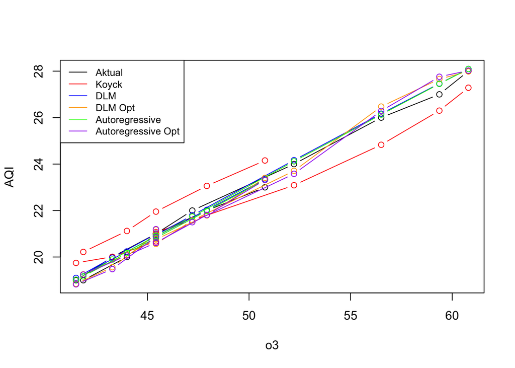

```r
plot(test$o3, test$AQI, type="b", col="black", ylim=range(c(test$AQI,
                                                           fore.koyck$forecasts,
                                                           fore.dlm$forecasts,
                                                           fore.dlm2$forecasts,
                                                           fore.ardl$forecasts,
                                                           fore.ardl2$forecasts)),
     xlab="o3", ylab="AQI")

lines(test$o3, fore.koyck$forecasts, col="red", type="b")
lines(test$o3, fore.dlm$forecasts, col="blue", type="b")
lines(test$o3, fore.dlm2$forecasts, col="orange", type="b")
lines(test$o3, fore.ardl$forecasts, col="green", type="b")
lines(test$o3, fore.ardl2$forecasts, col="purple", type="b")

legend("topleft",
       legend=c("Aktual", "Koyck","DLM","DLM Opt","Autoregressive", "Autoregressive Opt"),
       col=c("black","red","blue","orange","green","purple"),
       lty=1, cex=0.8)
```

**Kesimpulan:** Berdasarkan plot perbandingan, terlihat bahwa semua model secara umum mampu mengikuti tren data aktual, meskipun dengan tingkat kedekatan yang berbeda. **Model DLM (biru) dan Autoregressive (hijau)** cukup konsisten mendekati data aktual, sementara **Model Koyck (merah)** terlihat paling menyimpang dari garis data aktual secara keseluruhan.

Zifa Aura Rahman  
G1401231010